# **Tópicos: De qué están hablando los candidatos**

#### **José Manuel Magallanes Ph.D.**

[CRÉDITOS y CONDICIONES DE USO](https://rawgit.com/projectsUW/peru2016elections/master/Credits.html)

Aquí les mostraremos los tópicos que van emergiendo en el discurso de los candidatos. La data que usaremos es el contenido del Tweet (lo mismo que utilizamos en el post sobre *sentimientos y reacciones*).

Para proponer los tópicos, se ha usado la técnica conocida como Latent Dirichlet Allocation ([LDA](https://en.wikipedia.org/wiki/Latent_Dirichlet_allocation)) implementada en Python. En todos los casos se han solicitado determinar 3 tópicos e informamos sus niveles de coherencia: se espera que al avanzar la campaña, el discurso sea más consistente.

La medida de coherencia nos servirá para saber si la coherencia ha mejorado de manera comparativa o no entre candidatos; y si eso ayuda de comprender los resultados obtenidos, o no.

- 15 de julio al 31 de agosto.
- 1 de setiembre hasta antes del primer debate.
- Entre el primer debate y antes del segundo.
- Entre el segundo debate y el día de las elecciones.
- Tópicos de Muñoz
- Tópicos de Urresti
- Tópicos de Reggiardo
- Tópicos de Beingolea
- Tópicos de Belmont
- Tópicos de Zurek
- Tópicos de Salinas
- Tópicos de Columbus
- Tópicos de Castañeda
- Tópicos de Capuñay
- Tópicos de Cornejo
- Tópicos de Lay
- Tópicos de Velarde
- Tópicos de Fernández
- Tópicos de Guerra García
- Tópicos de Gagó
- Tópicos de Gómez Baca
- Tópicos de Ocrospoma
- Tópicos de Villacorta

## Jorge Muñoz

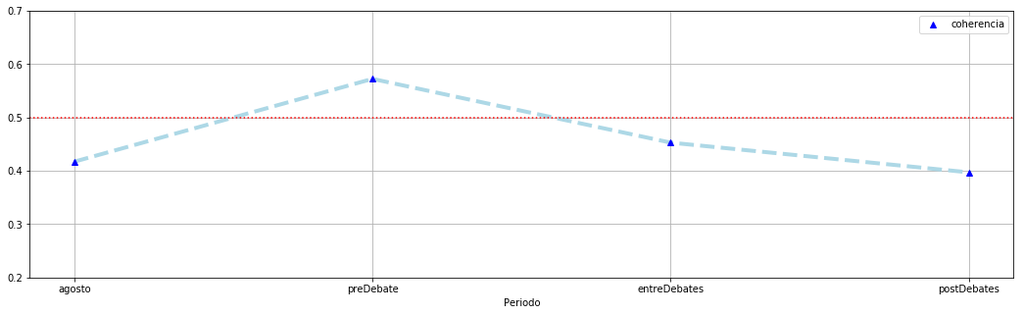

## Topicos

De click a un tópico y vea el conjunto característico de éstos.

Si no ir al siguiente candidato, o volver al inicio

**Antes de Setiembre**

[interactive chart not shown]

**1 de Setiembre hasta antes del debate**

[interactive chart not shown]

**Entre los dos debates**

[interactive chart not shown]

**Luego de Segundo debate hasta final de las elecciones**

[interactive chart not shown]

INICIO

## Daniel Urresti

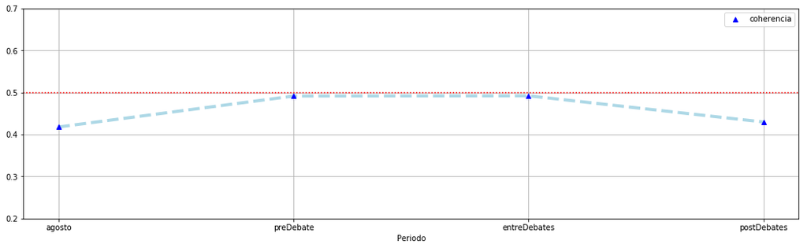

## Topicos

De click a un tópico y vea el conjunto característico de éstos.

Si no ir al siguiente candidato, o volver al inicio

**Antes de Setiembre**

[interactive chart not shown]

**1 de Setiembre hasta antes del debate**

[interactive chart not shown]

**Entre los dos debates**

[interactive chart not shown]

**Luego de Segundo debate hasta final de las elecciones**

[interactive chart not shown]

INICIO

## Renzo Reggiardo

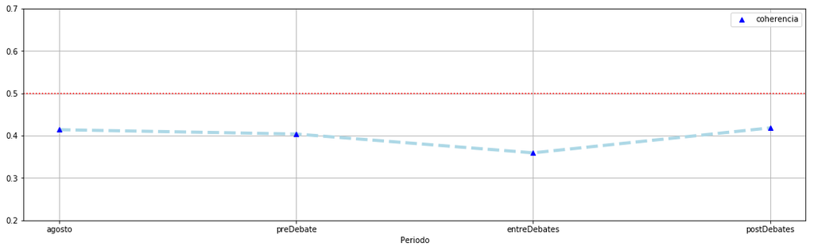

## Topicos

De click a un tópico y vea el conjunto característico de éstos.

Si no ir al siguiente candidato, o volver al inicio

**Antes de Setiembre**

[interactive chart not shown]

**1 de Setiembre hasta antes del debate**

[interactive chart not shown]

**Entre los dos debates**

[interactive chart not shown]

**Luego de Segundo debate hasta final de las elecciones**

[interactive chart not shown]

INICIO

## Alberto Beingolea

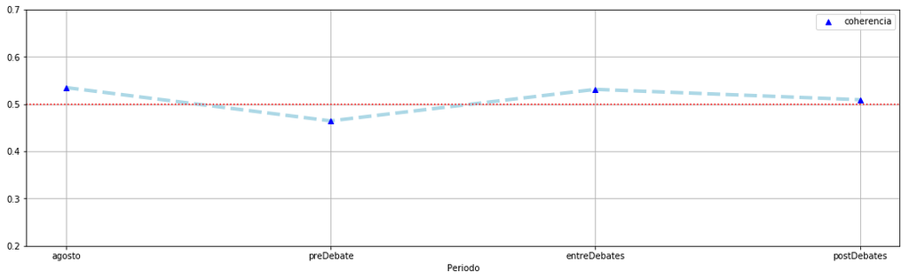

## Topicos

De click a un tópico y vea el conjunto característico de éstos.

Si no ir al siguiente candidato, o volver al inicio

**Antes de Setiembre**

[interactive chart not shown]

**1 de Setiembre hasta antes del debate**

[interactive chart not shown]

**Entre los dos debates**

[interactive chart not shown]

**Luego de Segundo debate hasta final de las elecciones**

[interactive chart not shown]

INICIO

## Ricardo Belmont

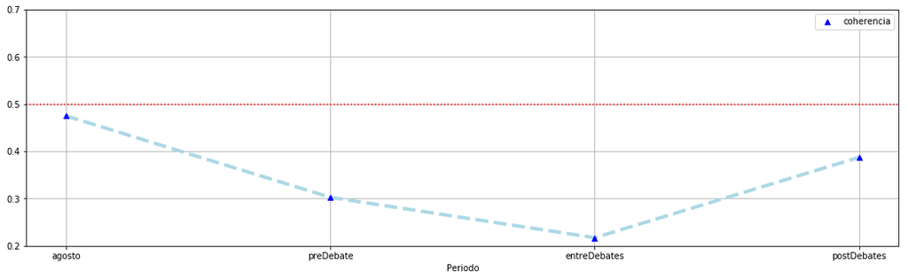

## Topicos

De click a un tópico y vea el conjunto característico de éstos.

Si no ir al siguiente candidato, o volver al inicio

**Antes de Setiembre**

[interactive chart not shown]

**1 de Setiembre hasta antes del debate**

[interactive chart not shown]

**Entre los dos debates**

[interactive chart not shown]

**Luego de Segundo debate hasta final de las elecciones**

[interactive chart not shown]

INICIO

## Juan Carlos Zurek

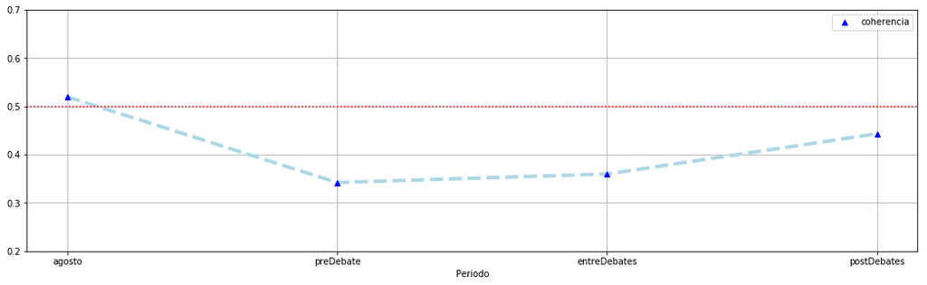

## Topicos

De click a un tópico y vea el conjunto característico de éstos.

Si no ir al siguiente candidato, o volver al inicio

**Antes de Setiembre**

[interactive chart not shown]

**1 de Setiembre hasta antes del debate**

[interactive chart not shown]

**Entre los dos debates**

[interactive chart not shown]

**Luego de Segundo debate hasta final de las elecciones**

[interactive chart not shown]

INICIO

## Jaime Salinas

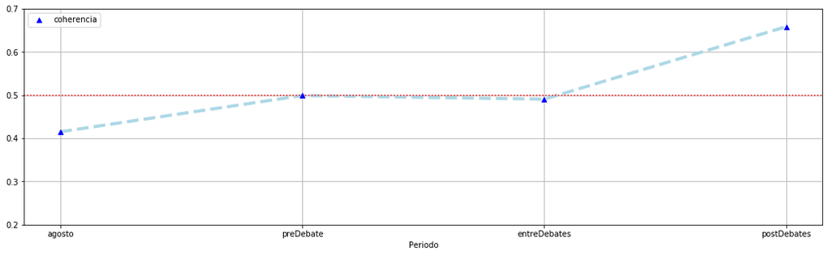

## Topicos

De click a un tópico y vea el conjunto característico de éstos.

Si no ir al siguiente candidato, o volver al inicio

**Antes de Setiembre**

[interactive chart not shown]

**1 de Setiembre hasta antes del debate**

[interactive chart not shown]

**Entre los dos debates**

[interactive chart not shown]

**Luego de Segundo debate hasta final de las elecciones**

[interactive chart not shown]

INICIO

## Diethell Columbus

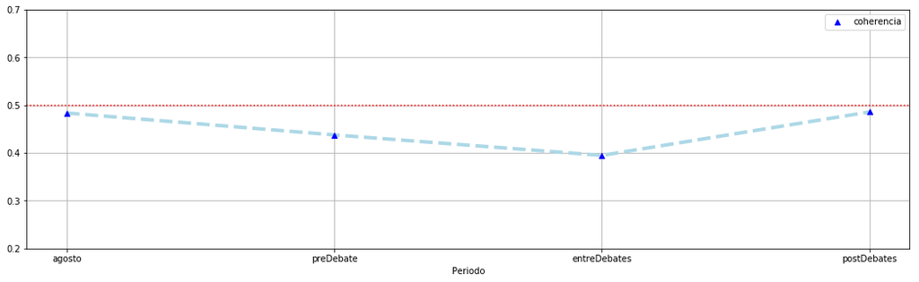

## Topicos

De click a un tópico y vea el conjunto característico de éstos.

Si no ir al siguiente candidato, o volver al inicio

**Antes de Setiembre**

[interactive chart not shown]

**1 de Setiembre hasta antes del debate**

[interactive chart not shown]

**Entre los dos debates**

[interactive chart not shown]

**Luego de Segundo debate hasta final de las elecciones**

[interactive chart not shown]

INICIO

## Luis Castañeda

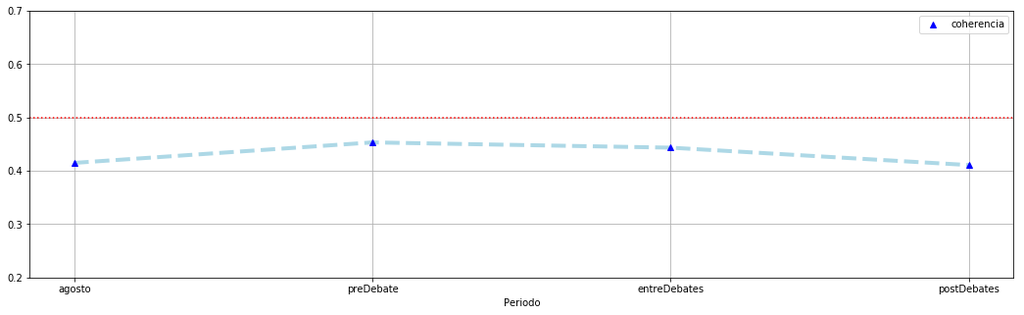

## Topicos

De click a un tópico y vea el conjunto característico de éstos.

Si no ir al siguiente candidato, o volver al inicio

**Antes de Setiembre**

[interactive chart not shown]

**1 de Setiembre hasta antes del debate**

[interactive chart not shown]

**Entre los dos debates**

[interactive chart not shown]

**Luego de Segundo debate hasta final de las elecciones**

[interactive chart not shown]

INICIO

## Esther Capuñay

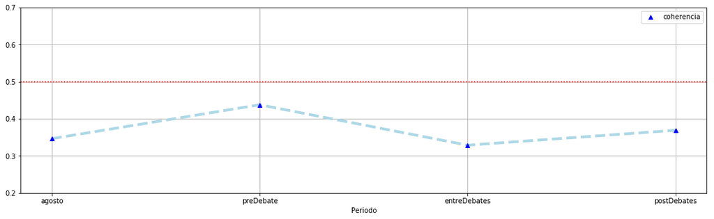

## Topicos

De click a un tópico y vea el conjunto característico de éstos.

Si no ir al siguiente candidato, o volver al inicio

**Antes de Setiembre**

[interactive chart not shown]

**1 de Setiembre hasta antes del debate**

[interactive chart not shown]

**Entre los dos debates**

[interactive chart not shown]

**Luego de Segundo debate hasta final de las elecciones**

[interactive chart not shown]

INICIO

## Enrique Cornejo

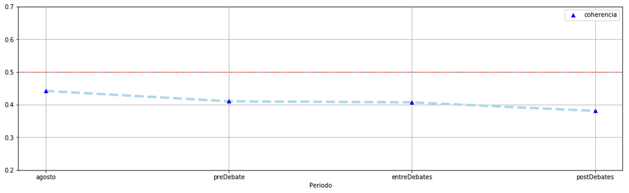

## Topicos

De click a un tópico y vea el conjunto característico de éstos.

Si no ir al siguiente candidato, o volver al inicio

**Antes de Setiembre**

[interactive chart not shown]

**1 de Setiembre hasta antes del debate**

[interactive chart not shown]

**Entre los dos debates**

[interactive chart not shown]

**Luego de Segundo debate hasta final de las elecciones**

[interactive chart not shown]

INICIO

## Humberto Lay

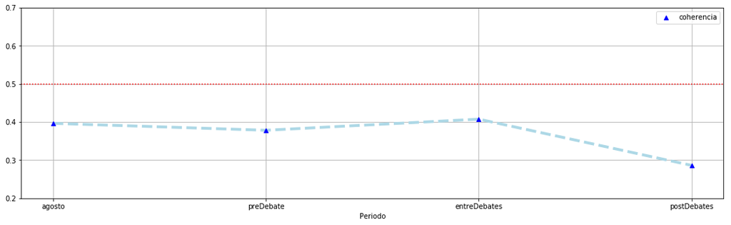

## Topicos

De click a un tópico y vea el conjunto característico de éstos.

Si no ir al siguiente candidato, o volver al inicio

**Antes de Setiembre**

[interactive chart not shown]

**1 de Setiembre hasta antes del debate**

[interactive chart not shown]

**Entre los dos debates**

[interactive chart not shown]

**Luego de Segundo debate hasta final de las elecciones**

[interactive chart not shown]

INICIO

## Manuel Velarde

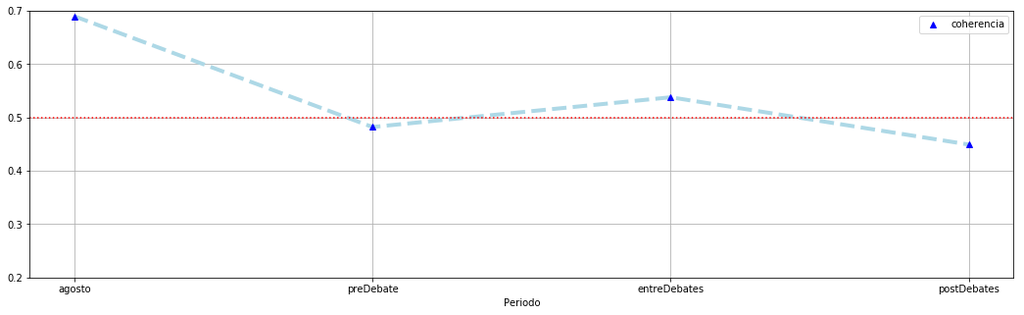

## Topicos

De click a un tópico y vea el conjunto característico de éstos.

Si no ir al siguiente candidato, o volver al inicio

**Antes de Setiembre**

[interactive chart not shown]

**1 de Setiembre hasta antes del debate**

[interactive chart not shown]

**Entre los dos debates**

[interactive chart not shown]

**Luego de Segundo debate hasta final de las elecciones**

[interactive chart not shown]

INICIO

## Carlos Fernández Chacón

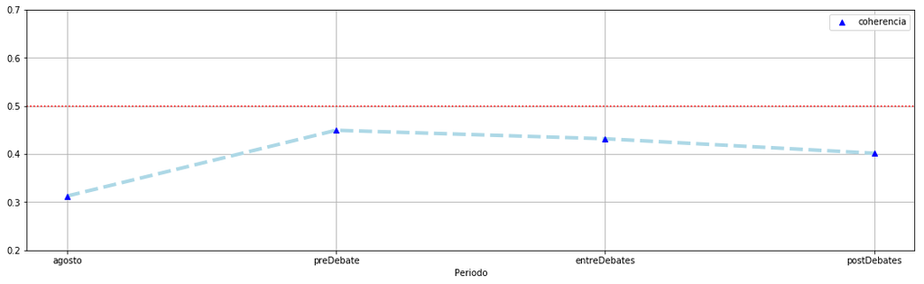

## Topicos

De click a un tópico y vea el conjunto característico de éstos.

Si no ir al siguiente candidato, o volver al inicio

**Antes de Setiembre**

[interactive chart not shown]

**1 de Setiembre hasta antes del debate**

[interactive chart not shown]

**Entre los dos debates**

[interactive chart not shown]

**Luego de Segundo debate hasta final de las elecciones**

[interactive chart not shown]

INICIO

## Gustavo Guerra García

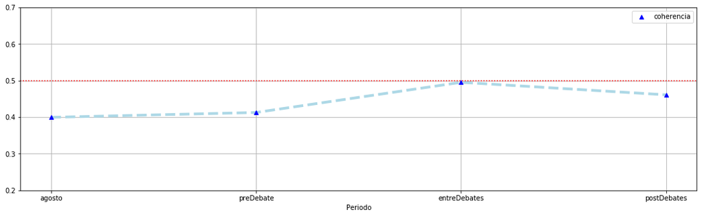

## Topicos

De click a un tópico y vea el conjunto característico de éstos.

Si no ir al siguiente candidato, o volver al inicio

**Antes de Setiembre**

[interactive chart not shown]

**1 de Setiembre hasta antes del debate**

[interactive chart not shown]

**Entre los dos debates**

[interactive chart not shown]

**Luego de Segundo debate hasta final de las elecciones**

[interactive chart not shown]

INICIO

## Julio Gagó

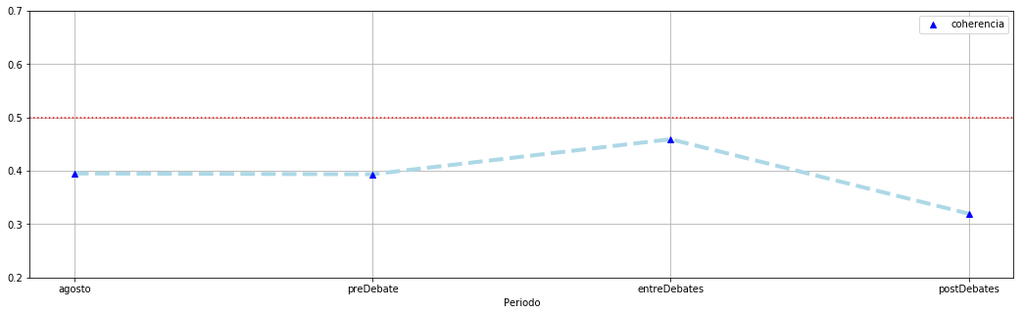

## Topicos

De click a un tópico y vea el conjunto característico de éstos.

Si no ir al siguiente candidato, o volver al inicio

**Antes de Setiembre**

[interactive chart not shown]

**1 de Setiembre hasta antes del debate**

[interactive chart not shown]

**Entre los dos debates**

[interactive chart not shown]

**Luego de Segundo debate hasta final de las elecciones**

[interactive chart not shown]

INICIO

## Roberto Gómez Baca

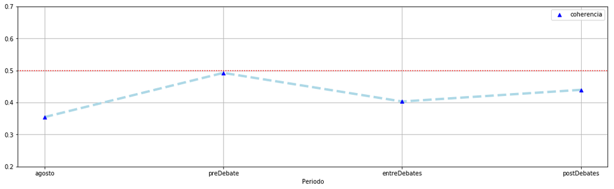

## Topicos

De click a un tópico y vea el conjunto característico de éstos.

Si no ir al siguiente candidato, o volver al inicio

**Antes de Setiembre**

[interactive chart not shown]

**1 de Setiembre hasta antes del debate**

[interactive chart not shown]

**Entre los dos debates**

[interactive chart not shown]

**Luego de Segundo debate hasta final de las elecciones**

[interactive chart not shown]

INICIO

## Enrique Ocrospoma

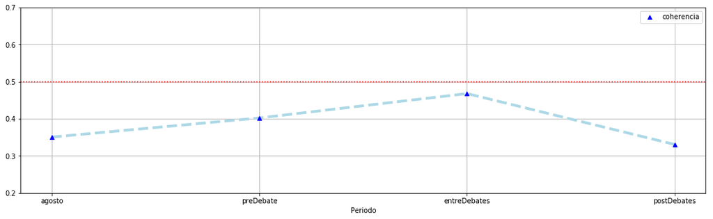

## Topicos

De click a un tópico y vea el conjunto característico de éstos.

Si no ir al siguiente candidato, o volver al inicio

**Antes de Setiembre**

[interactive chart not shown]

**1 de Setiembre hasta antes del debate**

[interactive chart not shown]

**Entre los dos debates**

[interactive chart not shown]

**Luego de Segundo debate hasta final de las elecciones**

[interactive chart not shown]

INICIO

## Jorge Villacorta

[figure not shown]

## Topicos

De click a un tópico y vea el conjunto característico de éstos.

**Antes de Setiembre**

[interactive chart not shown]

**1 de Setiembre hasta antes del debate**

[interactive chart not shown]

**Entre los dos debates**

[interactive chart not shown]

**Luego de Segundo debate hasta final de las elecciones**

[interactive chart not shown]

INICIO

[MENU](https://ermperu.github.io/elecciones2018/)